# Segment classes of the song types used in the phylogenetic analyses

- Show All Code
- Hide All Code
- View Source

Understanding cultural evolution of songs in hummingbird leks through the fossilized birth-death process

Author

[Marcelo Araya-Salas](https://marce10.github.io/)

Published

November 5, 2026

# Purpose

- Show the segment classes of each of the song types used in the RevBayes analyses on top of a spectrogram, to visually compare the different codings

# Load packages

```r
sketchy::load_packages(packages = c("knitr", "Rraven", "tuneR", "seewave", "viridis"))
knitr::opts_chunk$set(message = FALSE, warning = FALSE)
```

# Data

- **Song types**: all song types included in any of the RevBayes taxa sets (`data/processed/fossils/*_taxa_*.tsv`)
- **Recordings, contours and manual segments**: from the prevalence data set (`data/raw/segment_classification`), with the same corrections as in `automated_segment_classification.qmd` (segments annotated with the wrong song are reassigned; W converted to U)
- **20-segment codings**: produced in `segment_classification_20_segments.qmd`

```r
# song types in the RevBayes analyses
fs <- list.files("./data/processed/fossils", pattern = "taxa_.*\\.tsv$", full.names = TRUE)
rb_taxa <- unique(unlist(lapply(fs, function(f) read.delim(f)[[1]])))
rb_types <- sort(unique(sub("-[0-9]{4}$", "", rb_taxa)))

# contours and recording
contours <- read.csv("./data/raw/segment_classification/seltailor_output.csv")
ff_cols <- grep("^ff", names(contours))
wave <- readWave("./data/raw/segment_classification/contour-degradation_325_songs.wav")
sr <- wave@samp.rate

# manual (variable-length) segments with corrections
segs <- imp_raven(path = "./data/raw/segment_classification", files = "FrameworkContourDegradationv1.7.txt",
                  all.data = TRUE, warbler.format = TRUE)
segs <- segs[!is.na(segs$Category) & segs$Category != "" & segs$ID %in% contours$song.type, ]
tol <- 0.005
m <- match(segs$ID, contours$song.type)
outside <- segs$end < contours$start[m] - tol | segs$start > contours$end[m] + tol
segs$ID[outside] <- vapply(which(outside), function(i) {
  k <- which(contours$start <= segs$start[i] + tol & contours$end >= segs$end[i] - tol)
  if (length(k) == 1) contours$song.type[k] else NA_character_
}, character(1))
segs <- segs[!is.na(segs$ID), ]
segs$Category[segs$Category == "W"] <- "U"
segs <- segs[order(segs$ID, segs$start), ]

# 20-segment labels of each prevalence recording
S20 <- read.csv("./data/processed/segment_classifier_20/cv_predictions_20.csv")

# 20-segment sequences per song type
read_seqs <- function(f) {
  d <- read.csv(f); M <- toupper(as.matrix(d[, paste0("X", 1:20)])); rownames(M) <- d$song.type; M
}
cons_prev <- read_seqs("./data/processed/segments_by_song_type_prevalence.csv")
cons_2019 <- read_seqs("./data/processed/segments_by_song_type_corrected.csv")
used_trees <- read_seqs("./data/raw/segments_by_song_type.csv")

data.frame(song_types_in_RevBayes = length(rb_types),
           with_prevalence_recording = sum(rb_types %in% S20$lek.song.type),
           by_lek = paste(names(table(sub("-.*", "", rb_types))), table(sub("-.*", "", rb_types)), sep = ": ", collapse = ", "))
```

| song_types_in_RevBayes | with_prevalence_recording | by_lek |
| --- | --- | --- |
| 104 | 104 | BR1: 12, CCE: 21, HC1: 20, SUR: 38, TR1: 13 |

For each song type, the recording shown is the prevalence recording whose 20-segment labels best match the prevalence consensus of that song type (i.e. the most representative recording).

```r
pick_rendition <- function(ty) {
  ids <- unique(S20$ID[S20$lek.song.type == ty])
  score <- sapply(ids, function(id) {
    d <- S20[S20$ID == id, ]; d <- d[order(d$segment), ]
    mean(d$Category == cons_prev[ty, ])
  })
  ids[which.max(score)]
}
shown <- setNames(sapply(rb_types, pick_rendition), rb_types)
```

# Spectrograms

Each panel shows the spectrogram of one recording with the tailored frequency contour (orange) and, above it, five label strips:

1. **prevalence manual**: manually delimited segments of this recording (variable length; dashed lines on the spectrogram mark their boundaries)
2. **prevalence 20 seg**: the same recording converted to 20 equal-length segments (category covering most of each segment)
3. **prevalence consensus**: consensus across all prevalence recordings of the song type
4. **2019 corrected**: consensus of the 2019 coding, built in temporal order (`byrow = TRUE`)
5. **2019 used in trees**: the sequence used in the RevBayes analyses (`segments_by_song_type.csv`, built with `byrow = FALSE`, so not in temporal order)

The 20-segment strips (2 - 5) span the song from the start to the end of its contour, so positions can be compared with the spectrogram, although strips 3 - 5 are consensus sequences that are not specific to the recording shown. The panel title gives the number of prevalence recordings of the song type.

```r
cat_cols <- setNames(viridis(6, option = "H", begin = 0.05, end = 0.95), c("D", "U", "P", "F", "M", "S"))
txt_col <- setNames(c("white", "black", "black", "black", "black", "white"), names(cat_cols))

plot_song_type <- function(ty, margin = 0.008, flim = c(1, 11)) {
  id <- shown[[ty]]
  ct <- contours[contours$song.type == id, ]
  d <- segs[segs$ID == id, ]
  t0 <- max(0, ct$start - margin); t1 <- ct$end + margin
  clip <- cutw(wave, f = sr, from = t0, to = t1, output = "Wave")
  sp <- spectro(clip, f = sr, wl = 256, ovlp = 90, plot = FALSE, flim = c(0, 13))
  amp <- sp$amp; amp[amp < -45] <- -45
  tms <- sp$time * 1000
  ms <- function(x) (x - t0) * 1000

  strips <- list("prevalence manual" = NULL,
                 "prevalence 20 seg" = S20$Category[S20$ID == id][order(S20$segment[S20$ID == id])],
                 "prevalence consensus" = cons_prev[ty, ],
                 "2019 corrected" = if (ty %in% rownames(cons_2019)) cons_2019[ty, ] else NULL,
                 "2019 used in trees" = if (ty %in% rownames(used_trees)) used_trees[ty, ] else NULL)
  h <- 1.1; top <- flim[2] + h * length(strips)

  par(mar = c(3.5, 9, 2.2, 0.5))
  plot(NA, xlim = range(tms), ylim = c(flim[1], top), xaxs = "i", yaxs = "i", xlab = "", ylab = "", yaxt = "n",
       main = sprintf("%s   (recording shown: %s; %d prevalence recording(s))", ty, id, length(unique(S20$ID[S20$lek.song.type == ty]))),
       cex.main = 0.95)
  mtext("Time (ms)", side = 1, line = 2.2, cex = 0.8)
  axis(2, at = seq(ceiling(flim[1]), flim[2], 2), las = 1, cex.axis = 0.8)
  mtext("kHz", side = 2, line = 2.2, at = mean(flim), cex = 0.8)
  fsel <- sp$freq >= flim[1] & sp$freq <= flim[2]
  image(tms, sp$freq[fsel], t(amp[fsel, ]), col = gray.colors(40, start = 1, end = 0), add = TRUE, useRaster = TRUE)

  tt <- seq(ct$start, ct$end, length.out = length(ff_cols))
  lines(ms(tt), unlist(ct[, ff_cols]), col = "white", lwd = 3.5)
  lines(ms(tt), unlist(ct[, ff_cols]), col = "#FF8C00", lwd = 1.3)
  abline(v = ms(c(d$start, tail(d$end, 1))), lty = 2, col = "gray35")

  rect(min(tms), flim[2], max(tms), top, col = "white", border = NA)
  b20 <- ms(seq(ct$start, ct$end, length.out = 21))
  for (k in seq_along(strips)) {
    y0 <- top - k * h; y1 <- y0 + h
    if (k == 1) { xs <- ms(d$start); xe <- ms(d$end); lab <- d$Category } else {
      lab <- strips[[k]]; if (is.null(lab)) { text(mean(range(tms)), y0 + h / 2, "not available", cex = 0.7, col = "gray40"); next }
      xs <- b20[-21]; xe <- b20[-1]
    }
    rect(xs, y0, xe, y1, col = cat_cols[lab], border = "white", lwd = 0.5)
    text((xs + xe) / 2, y0 + h / 2, lab, col = txt_col[lab], cex = ifelse(k == 1, 0.8, 0.6), font = 2)
    mtext(names(strips)[k], side = 2, at = y0 + h / 2, las = 1, line = 0.3, cex = 0.65, adj = 1)
  }
  box()
}
```

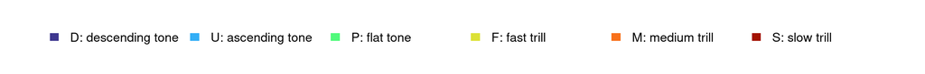

```r
par(mar = c(0, 0, 0, 0))
plot.new()
legend("center", horiz = TRUE, bty = "n", fill = cat_cols, border = NA, cex = 0.9,
       legend = c("D: descending tone", "U: ascending tone", "P: flat tone", "F: fast trill", "M: medium trill", "S: slow trill"))
```

```r
for (lk in unique(sub("-.*", "", rb_types))) {
  cat("\n\n## ", lk, "\n\n", sep = "")
  for (ty in rb_types[sub("-.*", "", rb_types) == lk]) {
    plot_song_type(ty)
    cat("\n\n")
  }
}
```

## BR1

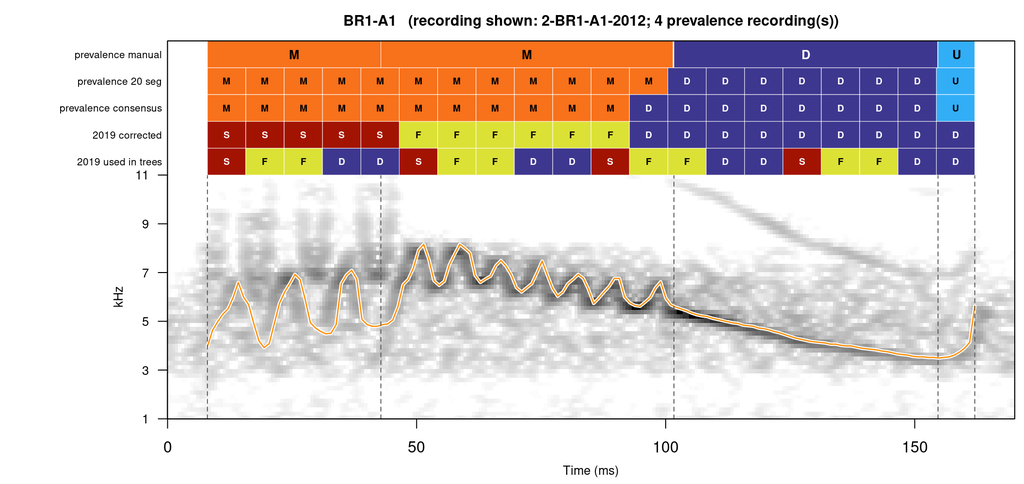

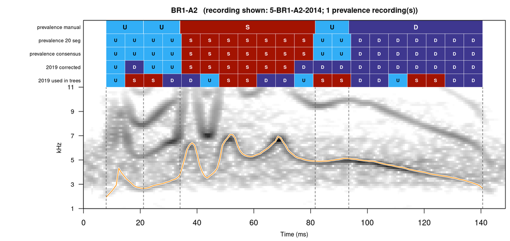

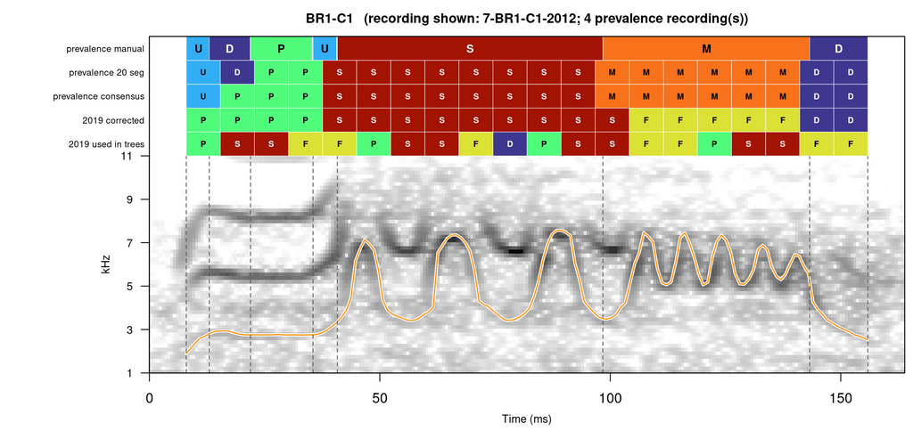

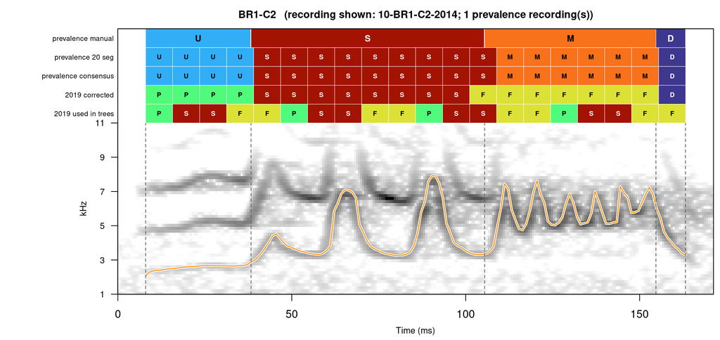

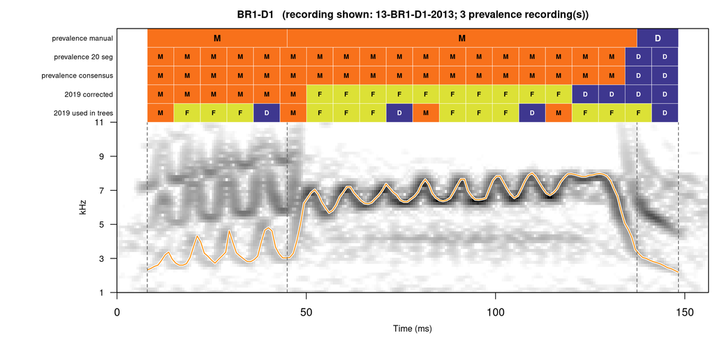

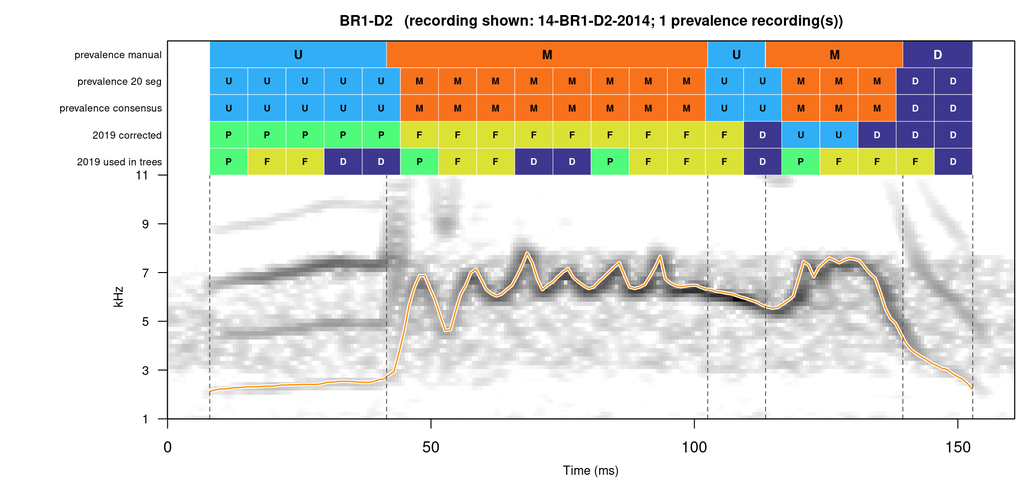

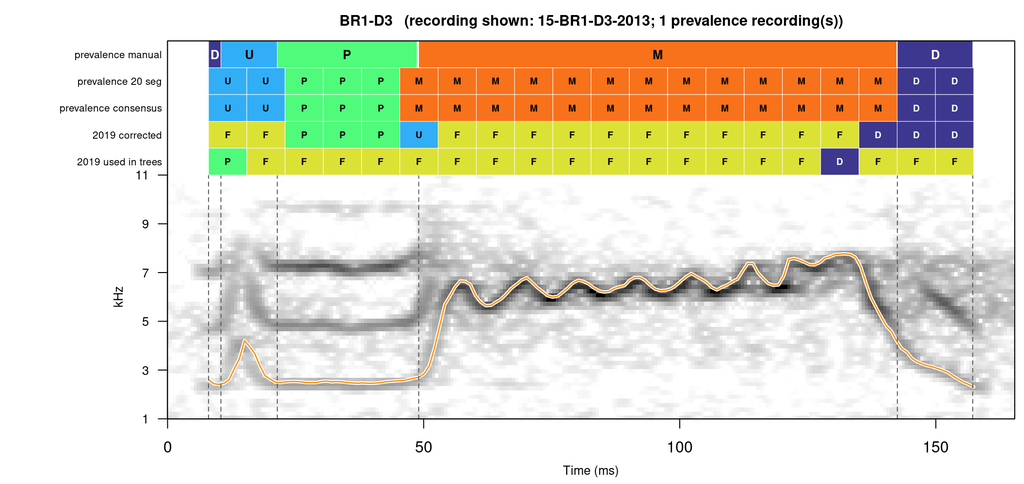

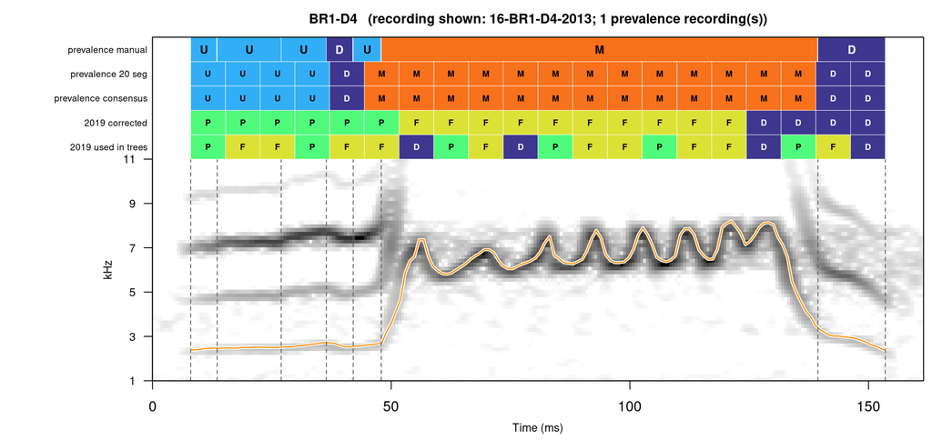

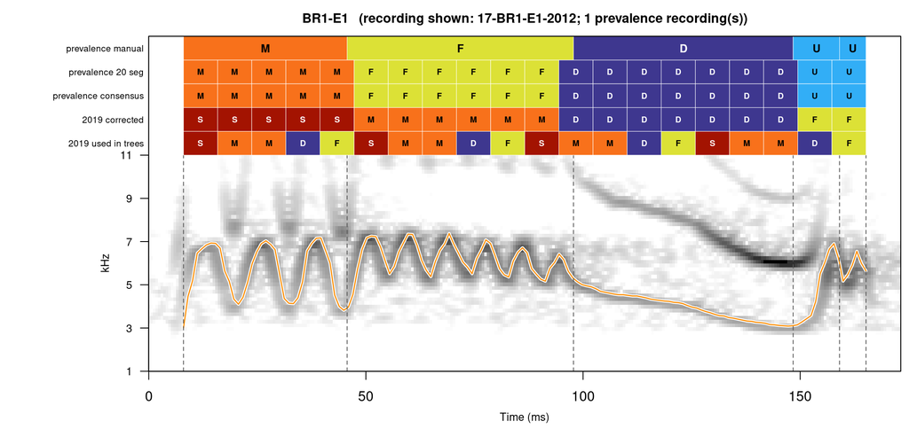

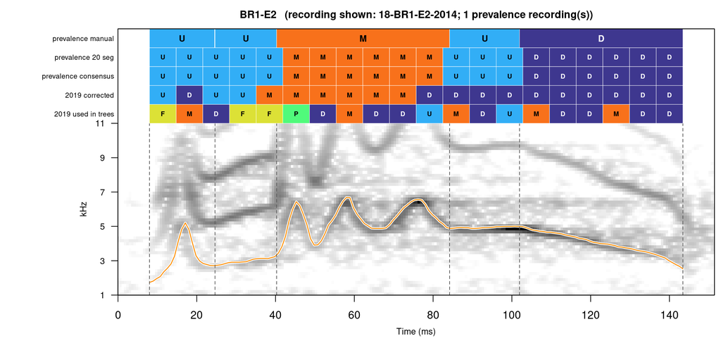

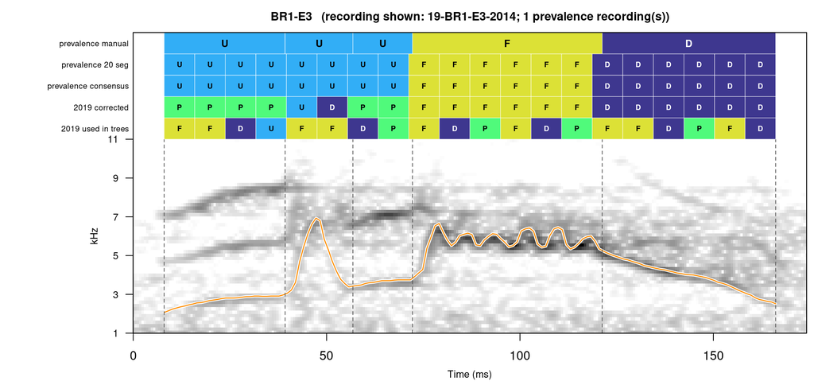

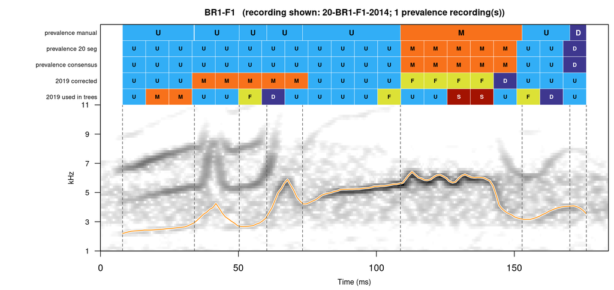

## CCE

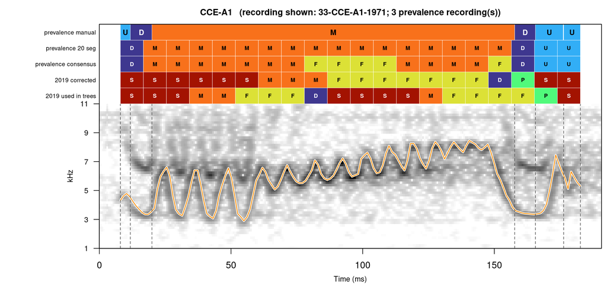

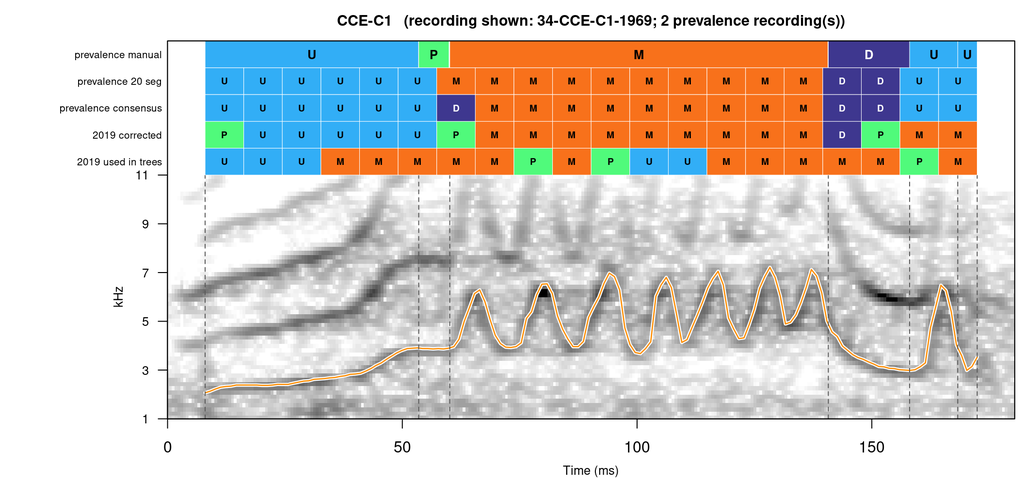

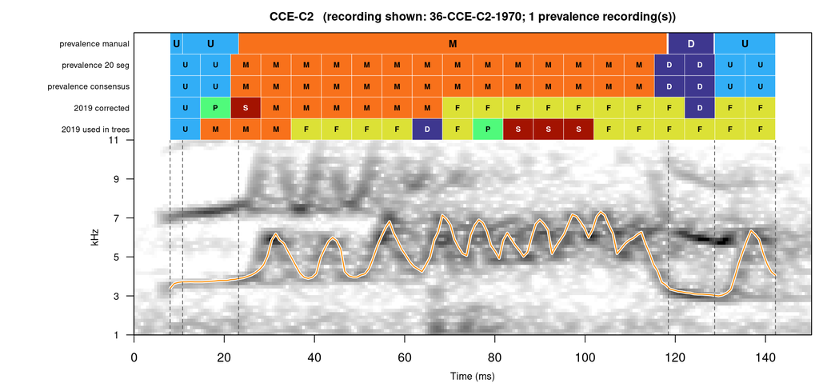

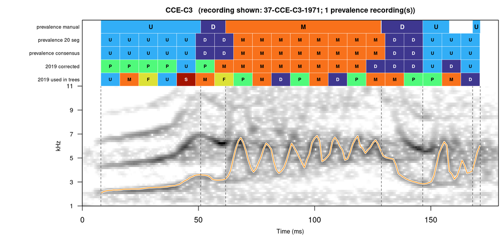

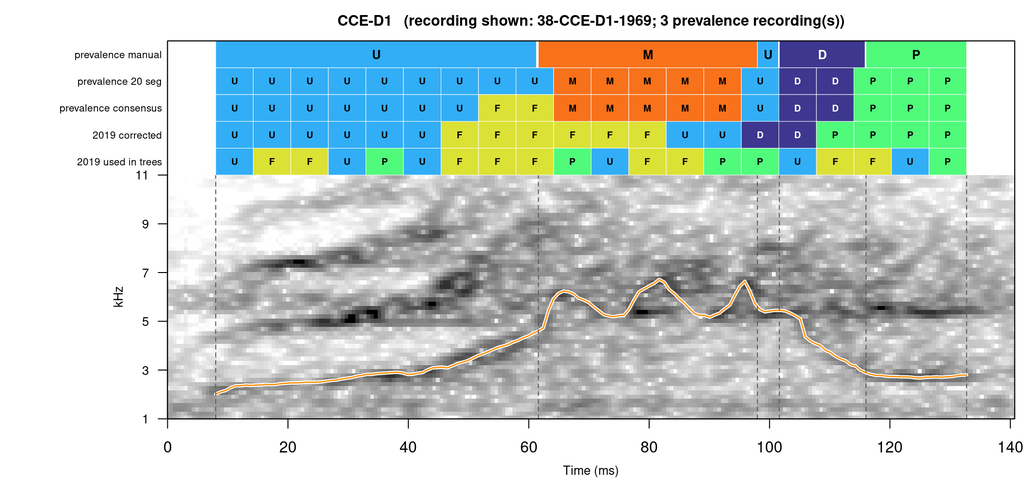

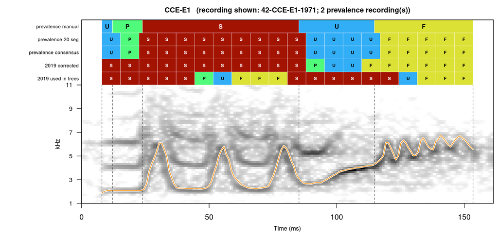

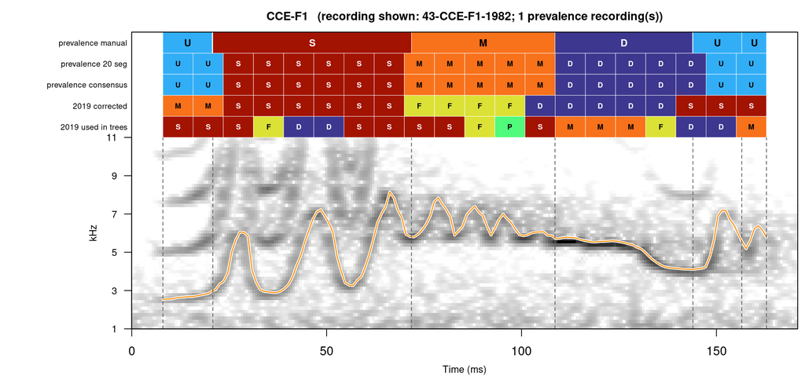

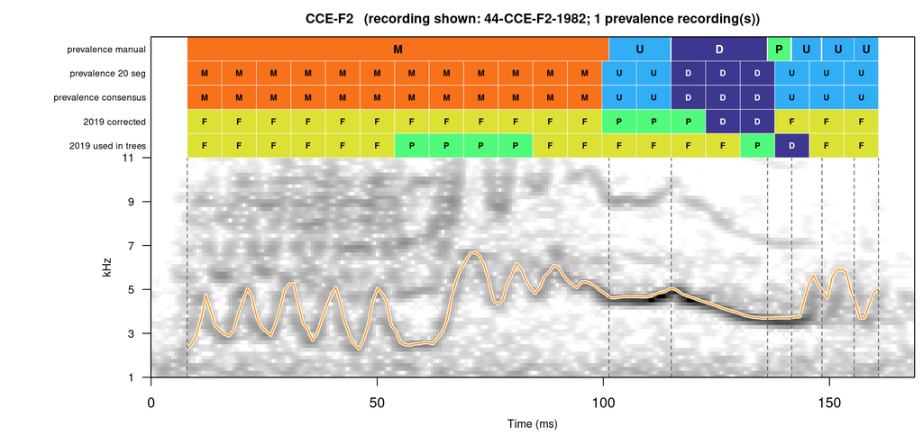

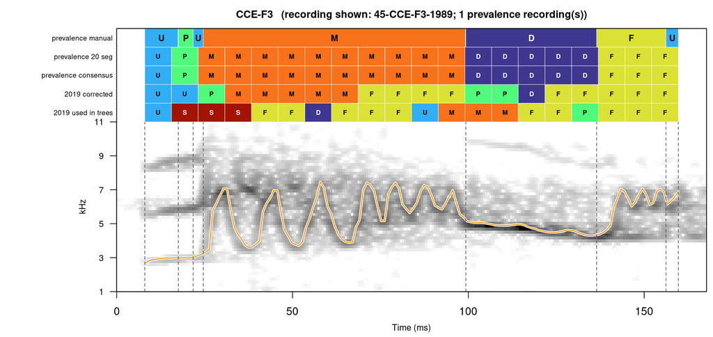

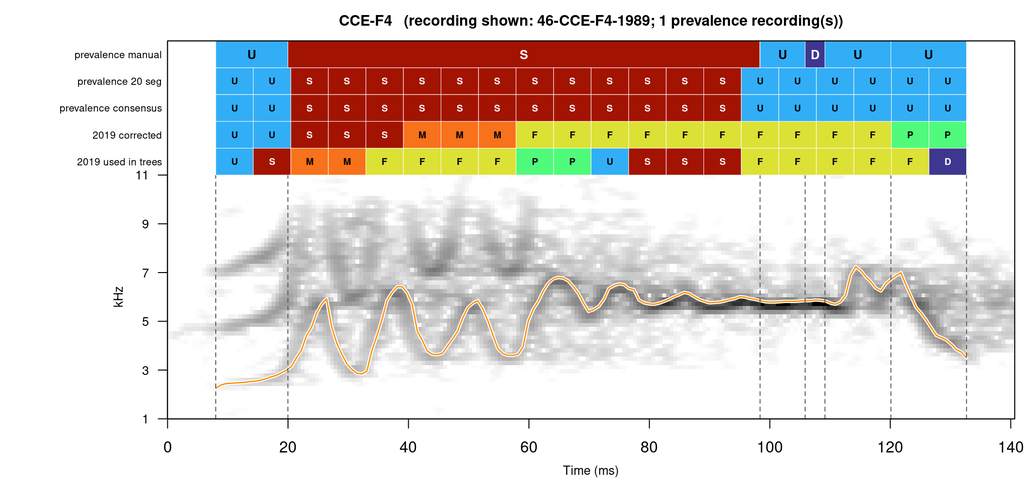

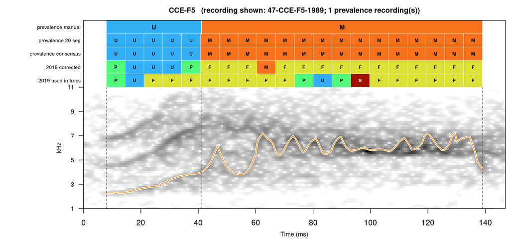

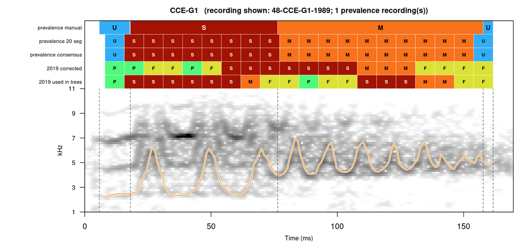

[9 more figures not shown]

## HC1

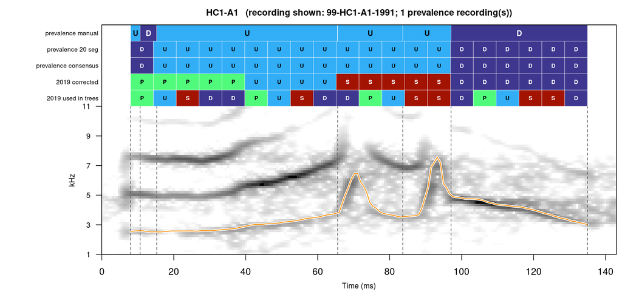

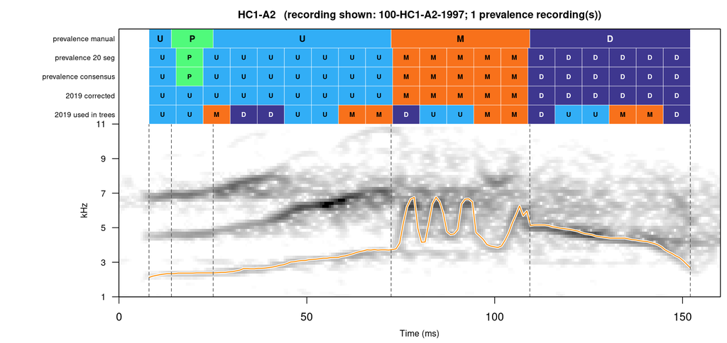

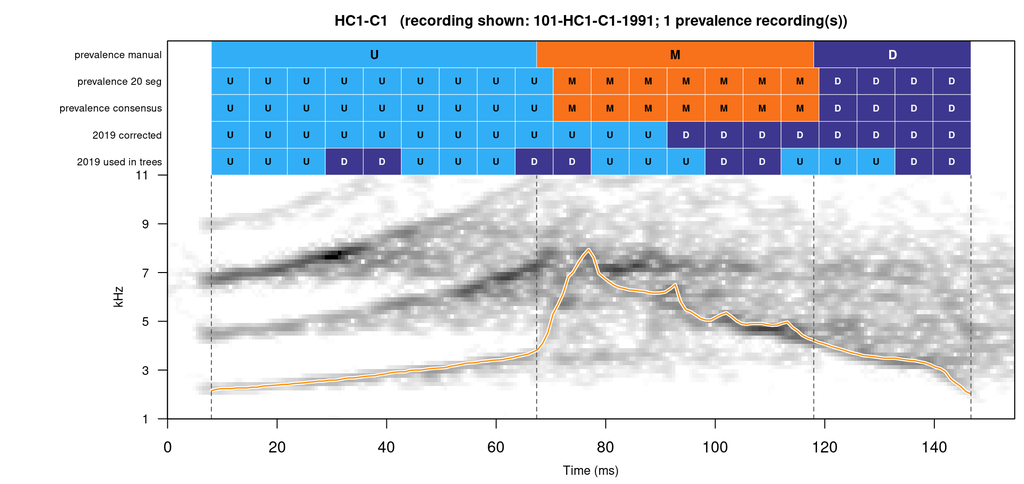

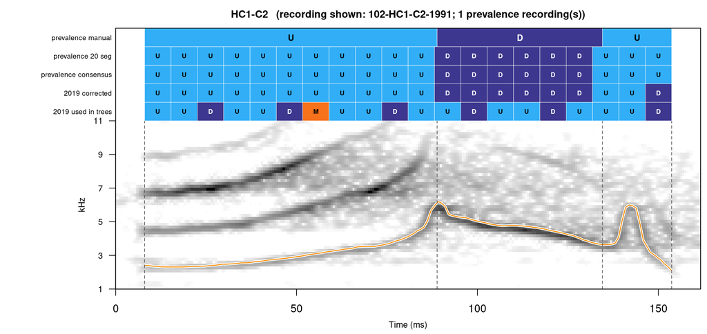

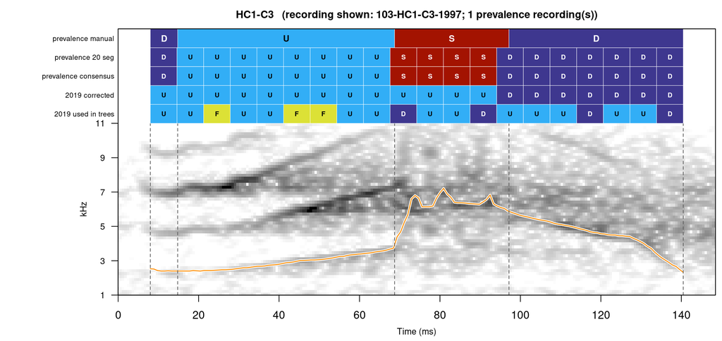

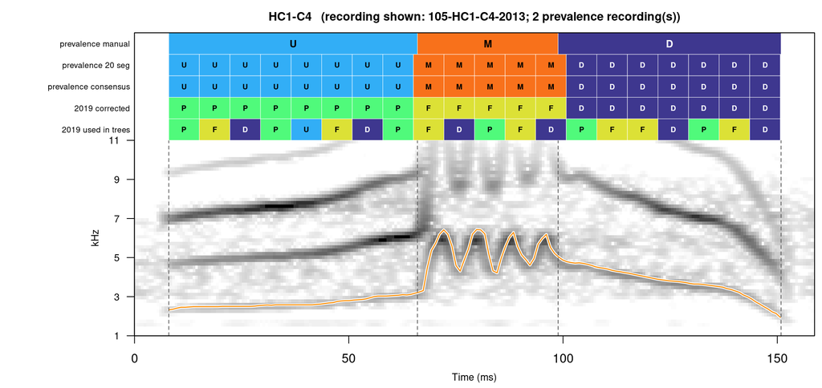